# Getting to know R(Studio)

Kendra Maas  
2015-06-15

### EtherPad

This is public, but I've used it in other software workshops and found it useful. I suggest using it when you are having issues with a command, post exactly what you are typing here so everyone can try to help you troubleshoot.

[etherpad](https://etherpad.mozilla.org/NjzjZnmTt9)

### Console

- Command line
- > prompt
- creating and object in R

```r
objectName <- values
```

```r
x <- 2+3
```

```r
x
```

```
[1] 5
```

```r
objectName <- values
```

- Read this objectName “gets” values
- shortcut Alt + - or Option + -
- can use = but this can lead to confusion when dealing with options
- There are lots of [keyboard shortcuts](https://support.rstudio.com/hc/en-us/articles/200711853-Keyboard-Shortcuts) to make your life easier
  - ctrl + Enter sends commands from Editor to Console
  - ctrl + `1` sends cursor to Editor
  - ctrl + `2` sends cursor to Console

### Names matter

- No spaces, commas, alphanumeric + . + _
- Names and variables must start with a letter
- Options for naming objects (files, variables, etc)

```r
lowerCamelCase
UpperCamelCase
i.use.periods
or_sometimes_underscores
```

Pick one of the naming conventions and try to stick with it

- Do as I say not as I do

### Try a few more

```r
r.rocks <- 2^4
```

```r
rRocks
```

```
Error: object 'rRocks' not found
```

```r
r.rocks
```

```
[1] 16
```

- Implicit contract with the computer or scripting language: Computer will do tedious computation for you. In return, you will be completely precise in your instructions.

### Object types

R has 5 basic (atomic) classes of objects

- character
- numeric
- integer
- complex
- logical (true/false)

### Numbers

- Numbers are generally treated as numeric unless specifically designated as integers
- `Inf` is a special number, can be used in calculations
  - `1/0` = `Inf`
  - `1/Inf` = `0`
- `NaN` is another special number, can be the result of calculations
  - `0/0` = `NaN`
  - I like `NaN` for missing variables

### Factors

- Can be letters/words or numbers
- USE WORDS, make your life easier when you open the file in 6 months
- Caution, values are stored as numbers. Can be coerced into acting like numbers
- Order is automatically sorted but you can reorder

Basic object is vector (atomic vector)

- Vector only has one class

```r
r.rocks
```

```
[1] 16
```

```r
seq(1,5)
```

```
[1] 1 2 3 4 5
```

- RStudio stored vectors under “Values”
- Do you see a vector for the seq(1,5) operation?

### Object Attributes

Objects can have attributes

- names, dimnames
- dimensions
- class
- length
- user defined metadata

### Metadata

[figure not shown]

> Metadata - Data about the data  
> Who, what, where, when, how of data generation

> > i.e. pH is data. The pH meter used, technician, date, location are metadata

### Back to Attributes

- view the attributes with

```r
attributes(r.rocks)
```

- We didn't assign any, and R doesn't automatically assign any for 1 value vectors

```r
str(r.rocks)
```

```
 num 16
```

```r
x <- seq(5, 18, 3)
```

```r
y <- cbind(x, r.rocks)
```

```r
attributes(y)
```

```
$dim
[1] 5 2

$dimnames
$dimnames[[1]]
NULL

$dimnames[[2]]
[1] "x"       "r.rocks"
```

```r
str(y)
```

```
 num [1:5, 1:2] 5 8 11 14 17 16 16 16 16 16
 - attr(*, "dimnames")=List of 2
  ..$ : NULL
  ..$ : chr [1:2] "x" "r.rocks"
```

Try `rbind(x, r.rocks)`

How do the structure and attributes change?

```r
z <- c(1, 32, 13.5)
```

c() concatenates values to make a vector

```r
str(z)
```

```
 num [1:3] 1 32 13.5
```

```r
z1 <- c("1", "foo", "TRUE")
```

```r
str(z1)
```

```
 chr [1:3] "1" "foo" "TRUE"
```

- If you mix object types, the vector will be `character`

### Common objects

- Vector
- List
- Matrix
- Array
- Tables
- **Data Frame**

### List

- Vector that can contain objects of different class
- Lists are useful but difficult to understand because they're usually not 2D tables
- Be aware that many functions output lists
- More about lists later

### Matrix/Array/Table

- Matrix-2D object
- Array-2D+ object
- Table-usually output, very similar to matrix
- All cells must be same type

### Data Frame

- Most common object you'll work with
- Column = variable =ish vector
- Each Column has same object type
- Columns with different types can be in one data frame
- Often have column and row names
- Becoming the default object type for many packages
- Almost always will be importing these data

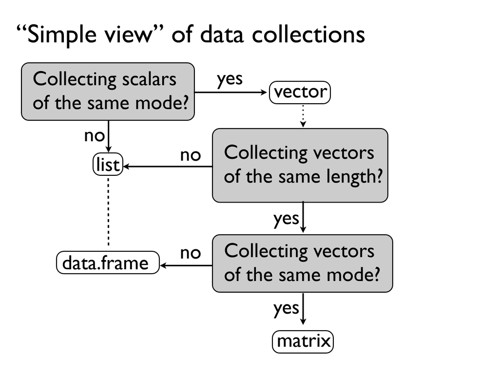

### Accessing bits of data

- Remember `z`

```r
z
```

```
[1]  1.0 32.0 13.5
```

- What's the first value of the first item in z?

```r
z[1]
```

```
[1] 1
```

- How about the third?

### Accessing bits of data

```r
(m <- matrix(1:16, nrow=4))
```

```
     [,1] [,2] [,3] [,4]
[1,]    1    5    9   13
[2,]    2    6   10   14
[3,]    3    7   11   15
[4,]    4    8   12   16
```

### Accessing bits of data

- What does the second column look like?

```r
m[,2]
```

```
[1] 5 6 7 8
```

- How about 4th row?

```r
m[4,]
```

```
[1]  4  8 12 16
```

- What number is in the third row, third column?
- Someone post the syntax for finding that on the etherpad
- `object[row,column]` is how you will access all sorts of data

### Workspace (aka Environment)

- Where every object you create exists
- Remove objects `rm(x)`
- Remove all objects rm(list=ls())
- Once you close R, everything in the workspace (and history) disappears
  - This is usually a good thing, don't save all the intermediate files
  - You can save your workspace as .RData
- Save individual (final) result to the current working directory
  - What is your current directory? Post it into the etherpad

### Better way to manage R

R Projects

- Creates folder in the working directory you set
- .Rproj is the basis for linking RStudio to GitHub R scripts
- Don't type in the console, type in a script file
  - Track what you've done
  - Easily repeat analyses
  - Don't have to recreate code when someone (often you) wants to do that `thing` again on a new dataset in a few months

### Packages

- The reason why R has become the default data analysis language
- Anyone can author a package
  - Must follow documentation guidelines
  - Must contain practice data
  - Most hosted on CRAN
  - `install.packages("packageName")`
  - Can use anyones in progress code by `source("script.name")`